# ExamenSimulacion

la Regresión Polinomial tiene una tendencia a ajustarse drásticamente, incluso es un simple conjunto de datos unidimensional. Si bien podamos tener una tentación de ajustar un polinomio de mayor grado para obtener un error menos, esto puede resultar en un ajuste excesivo, por esa razón siempre se debe trazar las relaciones para ver el ajuste y concentrarnos de que la curva se ajuste a la naturaleza del problema.

```python
import simpy
import random
import matplotlib.pyplot as pp
import time
m=round(media)
DIAS_SIMULACION=224
trabajadores_alimentacion={}
trabajadores_retail={}
trabajadores_restaurante={}
trabajadores_viajes={}
trabajadores_hoteles={}
trabajadores_desempleados={}

class ReinsercionLaboral(object):
    def __init__(self, env, valor):
        self.env = env
        self.valor = simpy.Resource(env, valor)

    def reintegracion_persona(self, actividad):
        if actividad == "alimentacion":
            trabajadores_alimentacion[env.now]=trabajadores_alimentacion[env.now]+ 1 if env.now in trabajadores_alimentacion else  1
        elif actividad == "retail":
            trabajadores_retail[env.now]=trabajadores_retail[env.now]+ 1 if env.now in trabajadores_retail else  1
        elif actividad == "restaurante y ocio":
            trabajadores_restaurante[env.now]=trabajadores_restaurante[env.now]+ 1 if env.now in trabajadores_restaurante else  1
        elif actividad == "viajes":
            trabajadores_viajes[env.now]=trabajadores_viajes[env.now]+ 1 if env.now in trabajadores_viajes else  1
        elif actividad == "hoteles":
            trabajadores_hoteles[env.now]=trabajadores_hoteles[env.now]+ 1 if env.now in trabajadores_hoteles else  1

    def teletrabajo(inicio, trabajador, actividad):
        yield inicio.env.timeout(random.randint(m-2, m+5))
        ##Tiempo de teletrabajo de 5 a 14 dias, se puso de 2 a 3 porque se iba a demorar mucho con todos los datos
    ## pero se podría poner el rango de 5 a 14, pero la salida de datos se demoraria más
        tiempo= random.randint(2,3)
        time.sleep(tiempo)
        valoracion= random.randint(0,100)
        #####La persona tiene una probabilidad del 70% para reintegrarse nuevamente a sus labores presenciales#########
        if(valoracion>30):
            print("El trabajador recuperado ", trabajador, " del area ", actividad, "se integra a laborar de forma presencial")
            env.process(inicio.reintegracion_persona(actividad))
            return
        else:
            print("El trabajador recuperado ", trabajador, " del area ", actividad, "vuelve al teletrabajo")
            env.process(inicio.teletrabajo(trabajador, actividad))

def reinsercion(inicio,env, trabajador):
    persona= random.randint(0,5)
    ##Determina el area del trabajador
    global actividad
    if persona == 0:
        actividad = "alimentacion"
    elif persona == 1:
        actividad = "retail"
    elif persona == 2:
        actividad = "restaurante y ocio"
    elif persona == 3:
        actividad = "viajes"
    elif persona == 4:
        actividad = "Hoteles"
    ##Tiempo de recuperación de 2 a 7 días en el domicilio, se puso de 1 a 2 porque se iba a demorar mucho con todos los datos
    ## pero se podría poner el rango de 2 a 7, pero la salida de datos se demoraria más
    tiempo= random.randint(1,2)
    time.sleep(tiempo)
    print("El trabajador recuperado ", trabajador, " del area ", actividad, "cumplio los 7 días de descanso ")
    tasa_desempleo= random.randint(0,100)
    if(tasa_desempleo>35):
        yield inicio.env.process(inicio.teletrabajo(trabajador, actividad))
    else:
        print("El trabajador recuperado ", trabajador, " del area ", actividad, "queda desempleado ")
        trabajadores_desempleados[env.now]=trabajadores_desempleados[env.now]+ 1 if env.now in trabajadores_desempleados else  1

def ejecutar(env, intervalo_llegada):
    inicio=ReinsercionLaboral(env, intervalo_llegada)
    for i in range(8000):
        yield env.timeout(1)
        env.process(reinsercion(inicio,env,i))

env=simpy.Environment()

env.process(ejecutar( env,m))

env.run(until =DIAS_SIMULACION)
print("TERMINO EL PROCESO")
```

[output not shown]

[output cut: 235 more lines]

[output not shown]

```
TRABAJADORES DESEMPLEADOS
```

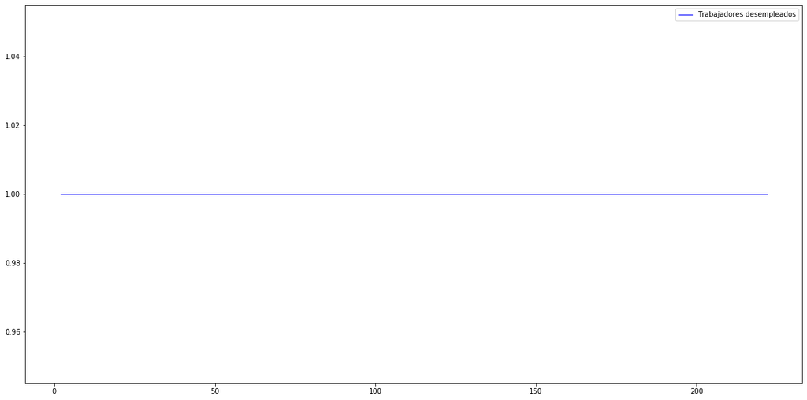

```python
datos=sorted(trabajadores_desempleados.items())
x, y =zip(*datos)

fig = plt.figure(figsize=(20, 10))

ax = fig.add_subplot(111,  axisbelow=True)
ax.plot(x, y, 'b', alpha=1, lw=1, label='Trabajadores desempleados')
legend = ax.legend()
print("TRABAJADORES DESEMPLEADOS")
```

**CONCLUSION**

Dentro del contexto de ocupación, que en otras palabras hace referencia al nivel de empleo en la nación es de mucha importancia especialmente en la parte de salud ocupacional, referida generalmente a la fuerza directamente productiva de una nación. Los riesgos ocupacionales necesitqar ser tomados en consideracion en los paises en desarrollo, no solamente por los problemas de indemnizacion que son fácilmente obviados por el desconocimiento o por la falta de un código sanitqario de trabajo, sino sobre todo para tomar medidas preventivas y curativas en el ambiente de trabajo que beneficiaran a todos los sectores, tanto patronales o estatales como de trabajodres de todos los rangos.